# CMSC320_Final_Tutorial

**Analysis of Drinking Water Types, Qualities, and Factors**

CMSC320 Final Tutorial

By: Isabella Battish, Janet Choi, Sarah Hwang

[Link to Data](https://dataverse.harvard.edu/dataset.xhtml?persistentId=doi:10.7910/DVN/DFB6NG)

Drinking water infrastructure is critical to a safe and healthy population. Every living being needs safe and clean drinking water, in fact, it's one of the [UN's Sustainable Development goals](https://sdgs.un.org/goals). While, the U.S. does have better drinking water quality and infrastructure compared to many places, the quality of drinking water is not equal everywhere in the U.S. The U.S. has old infrastructure and repairs and maintenance are lagging, especially in places with limited public spending. The older pipes can corrode and contaminate drinking water with materials we don't want to drink such as lead. The most famous recent (and ongoing) case of this is in Flint, Michigan where city employees tried to cut costs on water allowing 'hard' (mineral dense) water from the Flint River enter old pipes and corrode them so that they contaminated the drinking water with lead. Another famous example is from West Virginia where tap water was capable of catching on fire after a chemical that is used to clean coal was spilled into a nearby river. Other places that have had issues with water include Jackson, Mississippe, NYC, Baltimore, MD, and others. These cases show just how critical it is that we ensure our water quality and the infrastructure that brings us our water is up to date and properly functioning.

In this tutorial, we will walk you through the Data Science Pipeline.

1. Data Collection
2. Data Processing
3. Exploratory Analysis and Data Visualization
4. Anaylysis and Hypothesis Testing and Machine Learning
5. Insight and Policy Decision.

We hope that this walkthrough will show insights on the U.S. drinking water infrastructure, while also shedding light on potential risk areas in drinking water.

Throughout this tutorial we will analyze a variety of factors, and how they pertain to drinking water.

To learn more about drinking water crises in the U.S. please visit these links:

- https://www.pbs.org/newshour/show/why-american-cities-are-struggling-to-supply-safe-drinking-water
- https://www.npr.org/sections/thetwo-way/2016/04/20/465545378/lead-laced-water-in-flint-a-step-by-step-look-at-the-makings-of-a-crisis
- https://www.theatlantic.com/national/archive/2014/01/watch-west-virginia-man-set-tap-water-fire-after-local-chemical-spill/356920/

The first step in the Data Science pipeline is **Data Collection**. Data Collection can mean scraping data from a website using the Python BeautifulSoup library, using http requests to get data from a website, or using Pandas to read in a csv file into a data frame. In this project we will be reading in a csv file. The data in the csv file can be found at https://dataverse.harvard.edu/dataset.xhtml?persistentId=doi:10.7910/DVN/DFB6NG, download the file called MDWD.tab. The dataset is also called the Municipal Drinking Water Database (MDWD) and uses data from the Census and the EPA to help researchers interested in learning more about drinking water and factors that influence it. All we have to do is import all of our necessary imports for the tutorial, and run pd.read_csv. We call df.head() to show that we were successful in collecting our data.

```python
import pandas as pd
import seaborn as sns
from sklearn import svm
from sklearn.model_selection import train_test_split
from sklearn.metrics import classification_report
from sklearn.metrics import hinge_loss
import statsmodels.formula.api as smf

import numpy as np
import matplotlib.pyplot as plt
from matplotlib.colors import ListedColormap
from pandas.plotting import radviz
from sklearn.model_selection import train_test_split
from sklearn.neighbors import KNeighborsClassifier
from sklearn.utils import shuffle

import warnings
warnings.filterwarnings('ignore')
```

```python
df= pd.read_csv('MDWD.csv', encoding= 'latin-1')
df.head()
```

|  | PWSID | YEAR | FIPS_2000 | FIPS_2010 | FIPS | State | Census.Name | PWS.Name | GOVSid | FIPS_Code_State | ... | Water_Util_Construct_nonadjusted | Health_Total_Expend_nonadjusted | Parks___Rec_Total_Exp_nonadjusted | Police_Prot_Total_Exp_nonadjusted | Total_Debt_Outstanding_nonadjusted | Total_IG_Revenue_nonadjusted | Total_Rev_Own_Sources_nonadjusted | GW_SW_CODE | PRIMARY_SOURCE_CODE | demshare_pres_2016 |
| --- | --- | --- | --- | --- | --- | --- | --- | --- | --- | --- | --- | --- | --- | --- | --- | --- | --- | --- | --- | --- | --- |
| 0 | AL0000017 | 1997 | 162328 | 162328 | 162328 | AL | Prattville city | PRATTVILLE (WATER WORKS BOARD OF) | 12001003.0 | 1.0 | ... | 0.0 | 38000.0 | 1089000.0 | 2662000.0 | 36995000.0 | 956000.0 | 14363000.0 | SW | SWP | NaN |
| 1 | AL0000017 | 2012 | 162328 | 162328 | 162328 | AL | Prattville city | PRATTVILLE (WATER WORKS BOARD OF) | 12001003.0 | 1.0 | ... | 0.0 | 0.0 | 1749000.0 | 6204000.0 | 61237000.0 | 1000000.0 | 34705000.0 | SW | SWP | NaN |
| 2 | AL0000017 | 2017 | 162328 | 162328 | 162328 | AL | Prattville city | PRATTVILLE (WATER WORKS BOARD OF) | 12001003.0 | 1.0 | ... | 0.0 | 0.0 | 1801000.0 | 6909000.0 | 60511000.0 | 1349000.0 | 44552000.0 | SW | SWP | NaN |
| 3 | AL0000017 | 2007 | 162328 | 162328 | 162328 | AL | Prattville city | PRATTVILLE (WATER WORKS BOARD OF) | 12001003.0 | 1.0 | ... | 0.0 | 0.0 | 1797000.0 | 5506000.0 | 60581000.0 | 407000.0 | 28406000.0 | SW | SWP | NaN |
| 4 | AL0000017 | 1998 | 162328 | 162328 | 162328 | AL | Prattville city | PRATTVILLE (WATER WORKS BOARD OF) | NaN | NaN | ... | NaN | NaN | NaN | NaN | NaN | NaN | NaN | SW | SWP | NaN |

5 rows × 66 columns

The second step in the Data Science pipeline is **Data Processing**. In the data processing stage we 'clean' our data so it is an easy to understand and workable format. Our data has A LOT of columns, and we will not be using the data in all of those columns. To get rid of many of the columns we drop/delete all of the columns where financial expenses are 'nonadjusted'. The nonadjusted part means that it's the cost of something but not changed to reflect inflation. We only want the adjusted expenditures. Now our data is a little bit easier to read.

**RUN THIS BLOCK ONCE**

```python
df= df.drop(["Police_Prot_Total_Exp_nonadjusted"], axis= 1)
df= df.drop(["Water_Util_Current_Exp_nonadjusted"], axis= 1)
df= df.drop(["Water_Util_Construct_nonadjusted"], axis= 1)
df= df.drop(["Water_Util_Inter_Exp_nonadjusted"], axis= 1)
df= df.drop(["Health_Total_Expend_nonadjusted"], axis= 1)
df= df.drop(["Parks___Rec_Total_Exp_nonadjusted"], axis= 1)
df= df.drop(["Total_Debt_Outstanding_nonadjusted"], axis= 1)
df= df.drop(["Total_IG_Revenue_nonadjusted"], axis= 1)
df= df.drop(["Total_Rev_Own_Sources_nonadjusted"], axis= 1)
df= df.drop(["Total_Revenue_nonadjusted"], axis= 1)
df= df.drop(["Total_Expenditure_nonadjusted"], axis= 1)
df= df.drop(["Total_Taxes_nonadjusted"], axis= 1)
df= df.drop(["Water_Utility_Revenue_nonadjusted"], axis= 1)
df= df.drop(["Water_Util_Total_Exp_nonadjusted"], axis= 1)
df= df.drop(["Water_Util_Cap_Outlay_nonadjusted"], axis= 1)

#Some other columns we don't anticipate needing
df= df.drop(["Police_Prot_Total_Exp"], axis= 1)
df= df.drop(["Total_IG_Revenue"], axis= 1)
df= df.drop(["Total_Rev_Own_Sources"], axis= 1)
df= df.drop(['FIPS_2000'], axis= 1)
df= df.drop(['FIPS_2010'], axis= 1)
df= df.drop(['FIPS_Code_State'], axis= 1)
df= df.drop(['FIPS_County'], axis= 1)
df= df.drop(['FIPS'], axis= 1)
df= df.drop(['FIPS_Place'], axis= 1)
df= df.drop(['FIPS_Combined'], axis= 1)
#i think we should get rid of Name too
df= df.drop(['PWSID'], axis= 1)
df= df.drop(['Total_Expenditure'], axis= 1)
df= df.drop(['Total_Revenue'], axis= 1)
df= df.drop(['Water_Util_Inter_Exp'], axis= 1)
df= df.drop(['Water_Util_Cap_Outlay'], axis= 1)
df= df.drop(['Water_Util_Current_Exp'], axis= 1)
df= df.drop(['Parks___Rec_Total_Exp'], axis= 1)
df= df.drop(['Median_Housing_Age'], axis= 1)
df= df.drop(['PCT_25Plus_Bachelors'], axis= 1) #if the others don't seem interesting put back
df= df.drop(['PCT_25Plus_LessThanDiploma'], axis= 1)
df= df.drop(['Below18_Poverty'], axis= 1)
df= df.drop(['X18_64_Poverty'], axis= 1)
df= df.drop(['X65Plus_Poverty'], axis= 1)
df= df.drop(['POV_POP'], axis= 1)
df= df.drop(['merged_FOG'], axis= 1)
df= df.drop(['GW_SW_CODE'], axis= 1)
df.columns
```

```
Index(['YEAR', 'State', 'Census.Name', 'PWS.Name', 'GOVSid', 'Name',
       'Population', 'Total_Taxes', 'Water_Utility_Revenue',
       'Water_Util_Total_Exp', 'Water_Util_Construct', 'Health_Total_Expend',
       'Total_Debt_Outstanding', 'TOT_POP', 'PCT_White', 'PCT_Black',
       'PCT_Hispanic', 'Median_Income', 'POV_PCT', 'vio_count',
       'month_moisture', 'Full_Time_Equivalent_Employees', 'CPI',
       'PRIMARY_SOURCE_CODE', 'demshare_pres_2016'],
      dtype='object')
```

```python
df.head(5)
```

|  | YEAR | State | Census.Name | PWS.Name | GOVSid | Name | Population | Total_Taxes | Water_Utility_Revenue | Water_Util_Total_Exp | ... | PCT_Black | PCT_Hispanic | Median_Income | POV_PCT | vio_count | month_moisture | Full_Time_Equivalent_Employees | CPI | PRIMARY_SOURCE_CODE | demshare_pres_2016 |
| --- | --- | --- | --- | --- | --- | --- | --- | --- | --- | --- | --- | --- | --- | --- | --- | --- | --- | --- | --- | --- | --- |
| 0 | 1997 | AL | Prattville city | PRATTVILLE (WATER WORKS BOARD OF) | 12001003.0 | PRATTVILLE CITY | 24269.0 | 5.692212e+06 | 0.0 | 0.0 | ... | NaN | NaN | NaN | NaN | 0 | 0.29 | 265.0 | 160.500 | SWP | NaN |
| 1 | 2012 | AL | Prattville city | PRATTVILLE (WATER WORKS BOARD OF) | 12001003.0 | PRATTVILLE CITY | 34683.0 | 1.156258e+07 | 0.0 | 0.0 | ... | 16.84 | 2.77 | 58773.0 | 9.339197 | 0 | 0.05 | 328.0 | 229.594 | SWP | NaN |
| 2 | 2017 | AL | Prattville city | PRATTVILLE (WATER WORKS BOARD OF) | 12001003.0 | PRATTVILLE CITY | 35420.0 | 1.438194e+07 | 0.0 | 0.0 | ... | 19.20 | 3.94 | 59167.0 | 13.036330 | 0 | 0.38 | 330.0 | 245.120 | SWP | NaN |
| 3 | 2007 | AL | Prattville city | PRATTVILLE (WATER WORKS BOARD OF) | 12001003.0 | PRATTVILLE CITY | 31119.0 | 9.871131e+06 | 0.0 | 0.0 | ... | NaN | NaN | NaN | NaN | 0 | -0.07 | 347.0 | 207.342 | SWP | NaN |
| 4 | 1998 | AL | Prattville city | PRATTVILLE (WATER WORKS BOARD OF) | NaN | NaN | NaN | NaN | NaN | NaN | ... | NaN | NaN | NaN | NaN | 0 | 0.06 | NaN | 163.000 | SWP | NaN |

5 rows × 25 columns

**RUN THIS BLOCK ONCE**

```python
df_2016= df.loc[df['YEAR'] == 2016]
df= df.drop(['demshare_pres_2016'], axis= 1)
df_2016.head()
```

|  | YEAR | State | Census.Name | PWS.Name | GOVSid | Name | Population | Total_Taxes | Water_Utility_Revenue | Water_Util_Total_Exp | ... | PCT_Black | PCT_Hispanic | Median_Income | POV_PCT | vio_count | month_moisture | Full_Time_Equivalent_Employees | CPI | PRIMARY_SOURCE_CODE | demshare_pres_2016 |
| --- | --- | --- | --- | --- | --- | --- | --- | --- | --- | --- | --- | --- | --- | --- | --- | --- | --- | --- | --- | --- | --- |
| 20 | 2016 | AL | Prattville city | PRATTVILLE (WATER WORKS BOARD OF) | NaN | NaN | NaN | NaN | NaN | NaN | ... | 17.12 | 3.99 | 56364.0 | 10.513570 | 0 | -0.05 | NaN | 240.007 | SWP | 0.218242 |
| 42 | 2016 | AL | Fairhope city | FAIRHOPE WATER SYSTEM (CITY OF) | NaN | NaN | NaN | NaN | NaN | NaN | ... | 5.18 | 4.28 | 61723.0 | 9.996666 | 0 | 0.29 | NaN | 240.007 | GW | NaN |
| 64 | 2016 | AL | Eufaula city | EUFAULA WATER WORKS | NaN | NaN | NaN | NaN | NaN | NaN | ... | 49.97 | 5.59 | 33362.0 | 25.764500 | 0 | 0.05 | NaN | 240.007 | GW | 0.504314 |
| 86 | 2016 | AL | Anniston city | ANNISTON WATER & SEWER BOARD | NaN | NaN | NaN | NaN | NaN | NaN | ... | 49.46 | 1.78 | 30539.0 | 30.872060 | 0 | -0.06 | NaN | 240.007 | SW | 0.585927 |
| 108 | 2016 | AL | Oxford city | OXFORD WATER WORKS & SEWER BOARD | NaN | NaN | NaN | NaN | NaN | NaN | ... | 13.66 | 7.91 | 51928.0 | 11.225360 | 0 | -0.06 | NaN | 240.007 | SW | 0.355963 |

5 rows × 25 columns

```python
df = df[df['GOVSid'].notna()]
count_row = df.shape[0]
count_row # still a bunch of data after dropping NaN values so we are good
df.head()
```

|  | YEAR | State | Census.Name | PWS.Name | GOVSid | Name | Population | Total_Taxes | Water_Utility_Revenue | Water_Util_Total_Exp | ... | PCT_White | PCT_Black | PCT_Hispanic | Median_Income | POV_PCT | vio_count | month_moisture | Full_Time_Equivalent_Employees | CPI | PRIMARY_SOURCE_CODE |
| --- | --- | --- | --- | --- | --- | --- | --- | --- | --- | --- | --- | --- | --- | --- | --- | --- | --- | --- | --- | --- | --- |
| 0 | 1997 | AL | Prattville city | PRATTVILLE (WATER WORKS BOARD OF) | 12001003.0 | PRATTVILLE CITY | 24269.0 | 5.692212e+06 | 0.0 | 0.0000 | ... | NaN | NaN | NaN | NaN | NaN | 0 | 0.29 | 265.0 | 160.500 | SWP |
| 1 | 2012 | AL | Prattville city | PRATTVILLE (WATER WORKS BOARD OF) | 12001003.0 | PRATTVILLE CITY | 34683.0 | 1.156258e+07 | 0.0 | 0.0000 | ... | 79.96 | 16.84 | 2.77 | 58773.0 | 9.339197 | 0 | 0.05 | 328.0 | 229.594 | SWP |
| 2 | 2017 | AL | Prattville city | PRATTVILLE (WATER WORKS BOARD OF) | 12001003.0 | PRATTVILLE CITY | 35420.0 | 1.438194e+07 | 0.0 | 0.0000 | ... | 75.03 | 19.20 | 3.94 | 59167.0 | 13.036330 | 0 | 0.38 | 330.0 | 245.120 | SWP |
| 3 | 2007 | AL | Prattville city | PRATTVILLE (WATER WORKS BOARD OF) | 12001003.0 | PRATTVILLE CITY | 31119.0 | 9.871131e+06 | 0.0 | 0.0000 | ... | NaN | NaN | NaN | NaN | NaN | 0 | -0.07 | 347.0 | 207.342 | SWP |
| 8 | 2002 | AL | Prattville city | PRATTVILLE (WATER WORKS BOARD OF) | 12001003.0 | PRATTVILLE CITY | 24303.0 | 6.468594e+06 | 0.0 | 159533.0739 | ... | NaN | NaN | NaN | NaN | NaN | 0 | 0.02 | NaN | 179.900 | SWP |

5 rows × 24 columns

The third step in the Data Science Pipeline is **Exploratory Data Analysis and Data Visualization**. In this step we start to explore basic understandings of our data and any trends, patterns, and/or relationships in it. For our data visualization component, we will be using the Seaborn Python library.

For starters, we are curious if there's a relationship between where a municipalities drinking water is sourced and what percentage of the area voted for Hillary Clinton in the 2016 election.

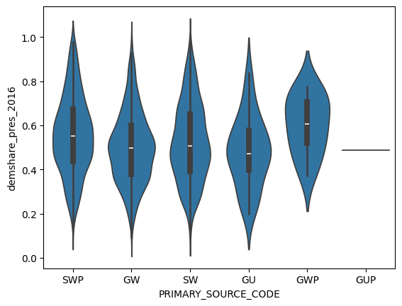

```python
sns.violinplot(x='PRIMARY_SOURCE_CODE', y='demshare_pres_2016',
             data=df_2016)
```

Interesting, our results don't show any relationship between the source of the water and the percentage of votes for the Democratic presidential candidate in 2016. For more context on what the source codes mean

- SWP= Purchased Surface Water
- SW= Surface Water
- GW= Ground Water
- GWP= Purchased Ground Water
- GU= Ground Water Influenced by Surface Water
- GUP= Purchased Ground Water Influenced by Surface Water

Surface water is water that is not underground, examples of this include rivers and reservoirs. While most places with surface water drinking sources are safe because the water is treated, surface water is most likely to be contaminated by external means. For example, in West Virginia a chemical spill into their river is what caused the drinking water to be contaminated, and in Flint, Michigan the Flint River's corrosiveness compared to ground water is what caused lead from the pipes to enter the drinking water supply.

Ground water is water from deep underground in deep wells and aquifers. The biggest and most famous aquifer in the U.S. is the Ogallala Aquifer. The Ogallala Aquifer runs underneath most of the Midwest and supplies water for the farms all over the place there. Unfortunately, the water supply is running out due to overusage. To learn more follow this [link](https://www.climate.gov/news-features/featured-images/national-climate-assessment-great-plains%E2%80%99-ogallala-aquifer-drying-out)

Ground water influenced by surface water means that the source of the water is groundwater but it's close enough to the surface to be influenced by surface water recharge, an example of this is springs and shallow wells and aquafers. This can lead to contaminants that aren't typically found in groundwater could be found in GU or GUP. To learn more about GU follow this [link](https://oehs.wvdhhr.org/eed/source-water-assessment-wellhead-protection/groundwater-under-direct-influence-of-surface-water-gwudi/).

There is also only one observation in 2016 that used GUP, let's explore that further. Based on the codeblock below, it looks like South Sioux City, Nebraska is the only municipality with purchased Ground Water Influenced by Surface Water.

```python
df_2016.loc[df_2016['PRIMARY_SOURCE_CODE']=='GUP']
```

|  | YEAR | State | Census.Name | PWS.Name | GOVSid | Name | Population | Total_Taxes | Water_Utility_Revenue | Water_Util_Total_Exp | ... | PCT_Black | PCT_Hispanic | Median_Income | POV_PCT | vio_count | month_moisture | Full_Time_Equivalent_Employees | CPI | PRIMARY_SOURCE_CODE | demshare_pres_2016 |
| --- | --- | --- | --- | --- | --- | --- | --- | --- | --- | --- | --- | --- | --- | --- | --- | --- | --- | --- | --- | --- | --- |
| 28554 | 2016 | NE | South Sioux City city | SOUTH SIOUX CITY, CITY OF | NaN | NaN | NaN | NaN | NaN | NaN | ... | 6.24 | 47.96 | 48438.0 | 19.12873 | 0 | 0.04 | NaN | 240.007 | GUP | 0.488197 |

1 rows × 25 columns

Now, we're curious if we can pick out years that had droughts or lots of rainfall. Let's make a lineplot of year and monthly moisture. We see a massive dip in 2012 indicating there was probably a drought in some places. Upon doing further research, there was a drought in 2012! To learn more about the Drought of 2012, click the link [here](https://www.weather.gov/iwx/2012_drought). Let's see if there is any obvious impact of state on monthly moisture as well. This graph is really hard to read due to do how many states there are but it doesn't seem to have too much of an impact on monthly moisture trends, beyond the fact that certain states get less rainfall than others.

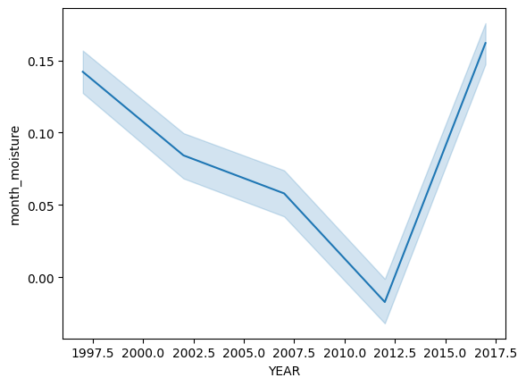

```python
sns.lineplot(x='YEAR', y='month_moisture',
             data=df)
```

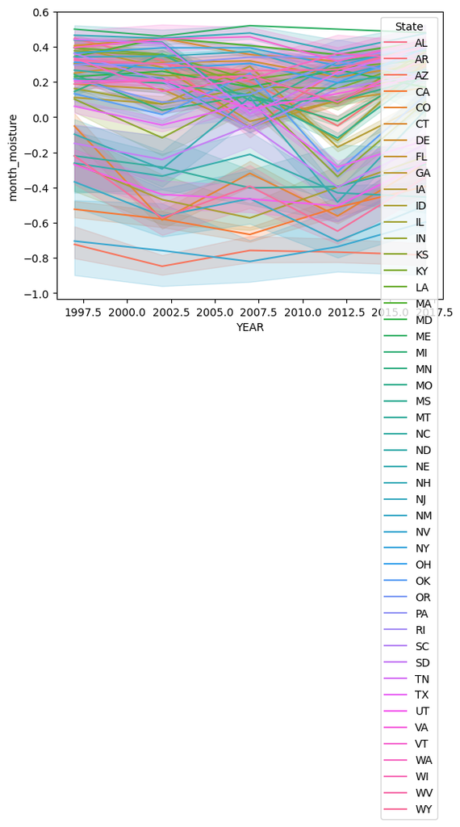

```python
sns.lineplot(x='YEAR', y='month_moisture', hue= 'State',
             data=df)
```

The next thing we want to see is if there is a relationship between the amount of monthly moisture and the source of a municipalities drinking water. Maybe if a place is dry they'll be more likely to use ground water or purchased water?

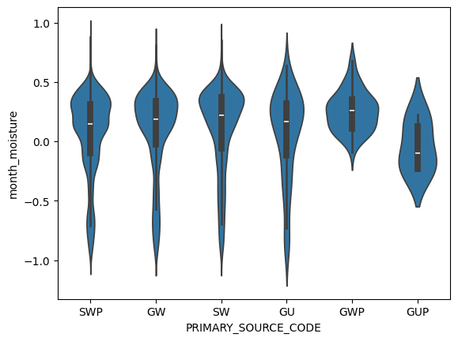

```python
sns.violinplot(x='PRIMARY_SOURCE_CODE', y='month_moisture',
             data=df)
```

Interesting, again we don't see tons of variance. The only point of interest is that areas that have purchased groundwater are more likely to have a higher moisture.

The last thing we'll look at is, if the 2012 drought influenced how much money municipalities spent on water. To do this, we'll look at the cost of water utilities before 2012, and during 2012.

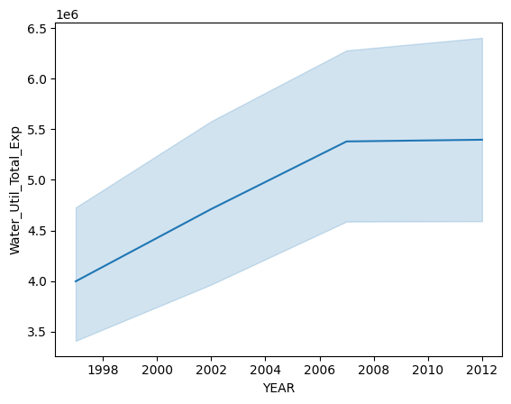

```python
df_pre2012= df.loc[df['YEAR'] <= 2012]

sns.lineplot(x= "YEAR", y= "Water_Util_Total_Exp", data= df_pre2012)
```

So here we noticed that the amount spent on water utilities by municipalities does increase from 1997 to 2007 but plateaus from 2007 to 2012. This doesn't support our suspicion that the 2012 drough would cause municipalities to spend more on water.

Next is step 4 of the Data Science Pipeline: **Analysis and Hypothesis Testing and Machine Learning**. In machine learning, analysis, and hypothesis testing we will use math and different model types to use our data to predict what the value of some other data might be. We will be using various variables related to drinking water with different factors about a municipality to predict as well. We will be using three different machine learning models to explore some different questions and areas of interest in drinking water infrastructure.The models we'll be using is Linear Regression with Gradient Descent, Support Vector Machine (SVM), and K-Nearest Neighbors (KNN).

To start, we'll create a correlation matrix to really explore relationships between the different variables we're exploring. We need to drop all columns with non-numeric variables since, you can't find a correlation between those.

```python
#creating correlation matrix so drop all non number columns
df2=df
df2= df2.drop(['State'], axis= 1)
df2= df2.drop(['Census.Name'], axis= 1)
df2= df2.drop(['PWS.Name'], axis= 1)
df2= df2.drop(['Name'], axis= 1)
df2= df2.drop(['PRIMARY_SOURCE_CODE'], axis= 1)

df2.corr()
#values closer to 1 or -1 have a high correlation in this
```

|  | YEAR | GOVSid | Population | Total_Taxes | Water_Utility_Revenue | Water_Util_Total_Exp | Water_Util_Construct | Health_Total_Expend | Total_Debt_Outstanding | TOT_POP | PCT_White | PCT_Black | PCT_Hispanic | Median_Income | POV_PCT | vio_count | month_moisture | Full_Time_Equivalent_Employees | CPI |
| --- | --- | --- | --- | --- | --- | --- | --- | --- | --- | --- | --- | --- | --- | --- | --- | --- | --- | --- | --- |
| YEAR | 1.000000 | -0.000430 | 0.018040 | 0.012647 | 0.048814 | 0.033224 | 0.017814 | 0.006778 | 0.014127 | 0.005935 | -0.034143 | 0.010318 | 0.030555 | 0.094912 | -0.002427 | -0.006872 | -0.024348 | -0.000102 | 0.996293 |
| GOVSid | -0.000430 | 1.000000 | -0.012775 | 0.007268 | -0.028452 | -0.025247 | -0.021499 | 0.026720 | 0.003755 | -0.011704 | 0.211243 | -0.092190 | -0.149825 | -0.026394 | -0.029181 | 0.031540 | 0.267338 | 0.012901 | -0.000457 |
| Population | 0.018040 | -0.012775 | 1.000000 | 0.841918 | 0.925352 | 0.905859 | 0.552076 | 0.723695 | 0.901420 | 0.999918 | -0.141991 | 0.067845 | 0.099029 | -0.018034 | 0.056756 | -0.009430 | -0.066297 | 0.879061 | 0.018123 |
| Total_Taxes | 0.012647 | 0.007268 | 0.841918 | 1.000000 | 0.697422 | 0.700557 | 0.202349 | 0.737445 | 0.972662 | 0.848244 | -0.066499 | 0.032957 | 0.026943 | -0.000589 | 0.019622 | 0.002890 | 0.003525 | 0.973552 | 0.012678 |
| Water_Utility_Revenue | 0.048814 | -0.028452 | 0.925352 | 0.697422 | 1.000000 | 0.965221 | 0.692938 | 0.602438 | 0.789943 | 0.940908 | -0.162475 | 0.091829 | 0.099566 | -0.023838 | 0.072449 | -0.013964 | -0.091381 | 0.722715 | 0.048463 |
| Water_Util_Total_Exp | 0.033224 | -0.025247 | 0.905859 | 0.700557 | 0.965221 | 1.000000 | 0.780865 | 0.591003 | 0.788630 | 0.935328 | -0.147047 | 0.080916 | 0.092855 | -0.021627 | 0.066280 | -0.012210 | -0.085059 | 0.721984 | 0.033049 |
| Water_Util_Construct | 0.017814 | -0.021499 | 0.552076 | 0.202349 | 0.692938 | 0.780865 | 1.000000 | 0.230278 | 0.324610 | 0.614373 | -0.095864 | 0.050656 | 0.085223 | -0.030873 | 0.060366 | -0.013402 | -0.086754 | 0.235542 | 0.017826 |
| Health_Total_Expend | 0.006778 | 0.026720 | 0.723695 | 0.737445 | 0.602438 | 0.591003 | 0.230278 | 1.000000 | 0.721610 | 0.691843 | -0.083335 | 0.058116 | 0.021982 | -0.018565 | 0.039070 | 0.004860 | 0.011662 | 0.755762 | 0.006866 |
| Total_Debt_Outstanding | 0.014127 | 0.003755 | 0.901420 | 0.972662 | 0.789943 | 0.788630 | 0.324610 | 0.721610 | 1.000000 | 0.911350 | -0.078288 | 0.042091 | 0.041548 | -0.012961 | 0.034373 | 0.001203 | -0.011112 | 0.956035 | 0.014549 |
| TOT_POP | 0.005935 | -0.011704 | 0.999918 | 0.848244 | 0.940908 | 0.935328 | 0.614373 | 0.691843 | 0.911350 | 1.000000 | -0.142212 | 0.068333 | 0.098501 | -0.018244 | 0.057147 | -0.002451 | -0.068238 | 0.871993 | 0.005935 |
| PCT_White | -0.034143 | 0.211243 | -0.141991 | -0.066499 | -0.162475 | -0.147047 | -0.095864 | -0.083335 | -0.078288 | -0.142212 | 1.000000 | -0.828328 | -0.199015 | 0.214452 | -0.415456 | 0.007756 | 0.052841 | -0.080417 | -0.034143 |
| PCT_Black | 0.010318 | -0.092190 | 0.067845 | 0.032957 | 0.091829 | 0.080916 | 0.050656 | 0.058116 | 0.042091 | 0.068333 | -0.828328 | 1.000000 | -0.116750 | -0.332489 | 0.468315 | -0.015129 | 0.157178 | 0.050108 | 0.010318 |
| PCT_Hispanic | 0.030555 | -0.149825 | 0.099029 | 0.026943 | 0.099566 | 0.092855 | 0.085223 | 0.021982 | 0.041548 | 0.098501 | -0.199015 | -0.116750 | 1.000000 | -0.150316 | 0.235008 | 0.030300 | -0.522032 | 0.027949 | 0.030555 |
| Median_Income | 0.094912 | -0.026394 | -0.018034 | -0.000589 | -0.023838 | -0.021627 | -0.030873 | -0.018565 | -0.012961 | -0.018244 | 0.214452 | -0.332489 | -0.150316 | 1.000000 | -0.769474 | -0.045830 | 0.054325 | -0.012947 | 0.094912 |
| POV_PCT | -0.002427 | -0.029181 | 0.056756 | 0.019622 | 0.072449 | 0.066280 | 0.060366 | 0.039070 | 0.034373 | 0.057147 | -0.415456 | 0.468315 | 0.235008 | -0.769474 | 1.000000 | 0.035717 | -0.052461 | 0.034332 | -0.002427 |
| vio_count | -0.006872 | 0.031540 | -0.009430 | 0.002890 | -0.013964 | -0.012210 | -0.013402 | 0.004860 | 0.001203 | -0.002451 | 0.007756 | -0.015129 | 0.030300 | -0.045830 | 0.035717 | 1.000000 | -0.005761 | 0.003184 | -0.004872 |
| month_moisture | -0.024348 | 0.267338 | -0.066297 | 0.003525 | -0.091381 | -0.085059 | -0.086754 | 0.011662 | -0.011112 | -0.068238 | 0.052841 | 0.157178 | -0.522032 | 0.054325 | -0.052461 | -0.005761 | 1.000000 | 0.006828 | -0.036083 |
| Full_Time_Equivalent_Employees | -0.000102 | 0.012901 | 0.879061 | 0.973552 | 0.722715 | 0.721984 | 0.235542 | 0.755762 | 0.956035 | 0.871993 | -0.080417 | 0.050108 | 0.027949 | -0.012947 | 0.034332 | 0.003184 | 0.006828 | 1.000000 | -0.000280 |
| CPI | 0.996293 | -0.000457 | 0.018123 | 0.012678 | 0.048463 | 0.033049 | 0.017826 | 0.006866 | 0.014549 | 0.005935 | -0.034143 | 0.010318 | 0.030555 | 0.094912 | -0.002427 | -0.004872 | -0.036083 | -0.000280 | 1.000000 |

So we do some Ordinary Least Squares (OLS). OLS is a regression model that will help us establish a relationship between our variables better and get some more descriptive statistics. So we run an OLS model with our dependent variable (what we're predicting) as Water Utility Revenue and our independent variables (what we're basing our prediction on) as Population, Health Expenditures, Total Outstanding Debt, and Percent of Population in Poverty.

```python
# seeing the summary stats from the regression model
ols_fit = smf.ols(formula=" Water_Utility_Revenue ~ Population * Health_Total_Expend * Total_Debt_Outstanding * POV_PCT", data=df2).fit()
print(ols_fit.summary())
```

```
                              OLS Regression Results
=================================================================================
Dep. Variable:     Water_Utility_Revenue   R-squared:                       0.717
Model:                               OLS   Adj. R-squared:                  0.717
Method:                    Least Squares   F-statistic:                     1592.
Date:                   Sat, 18 May 2024   Prob (F-statistic):               0.00
Time:                           21:50:37   Log-Likelihood:                -77398.
No. Observations:                   4401   AIC:                         1.548e+05
Df Residuals:                       4393   BIC:                         1.549e+05
Df Model:                              7
Covariance Type:               nonrobust
=================================================================================================================================
                                                                    coef    std err          t      P>|t|      [0.025      0.975]
---------------------------------------------------------------------------------------------------------------------------------
Intercept                                                      1.245e-19   1.42e-20      8.754      0.000    9.66e-20    1.52e-19
Population                                                    -2.757e-09   3.15e-10     -8.755      0.000   -3.37e-09   -2.14e-09
Health_Total_Expend                                            1.928e-12    2.2e-13      8.748      0.000     1.5e-12    2.36e-12
Population:Health_Total_Expend                                 3.306e-06   3.78e-07      8.751      0.000    2.57e-06    4.05e-06
Total_Debt_Outstanding                                        -3.409e-10    3.9e-11     -8.750      0.000   -4.17e-10   -2.64e-10
Population:Total_Debt_Outstanding                              4.877e-08   3.94e-09     12.387      0.000     4.1e-08    5.65e-08
Health_Total_Expend:Total_Debt_Outstanding                    -2.002e-09   2.04e-10     -9.834      0.000    -2.4e-09    -1.6e-09
Population:Health_Total_Expend:Total_Debt_Outstanding         -2.382e-16   1.67e-17    -14.263      0.000   -2.71e-16   -2.05e-16
POV_PCT                                                        5.698e-19   6.51e-20      8.754      0.000    4.42e-19    6.97e-19
Population:POV_PCT                                            -1.508e-13   1.72e-14     -8.741      0.000   -1.85e-13   -1.17e-13
Health_Total_Expend:POV_PCT                                   -1.309e-10    1.5e-11     -8.751      0.000    -1.6e-10   -1.02e-10
Population:Health_Total_Expend:POV_PCT                        -1.382e-07   1.58e-08     -8.756      0.000   -1.69e-07   -1.07e-07
Total_Debt_Outstanding:POV_PCT                                -5.247e-09      6e-10     -8.751      0.000   -6.42e-09   -4.07e-09
Population:Total_Debt_Outstanding:POV_PCT                     -1.716e-09   1.86e-10     -9.233      0.000   -2.08e-09   -1.35e-09
Health_Total_Expend:Total_Debt_Outstanding:POV_PCT             8.163e-11    8.8e-12      9.273      0.000    6.44e-11    9.89e-11
Population:Health_Total_Expend:Total_Debt_Outstanding:POV_PCT  1.289e-17   9.09e-19     14.186      0.000    1.11e-17    1.47e-17
==============================================================================
Omnibus:                     4675.278   Durbin-Watson:                   0.892
Prob(Omnibus):                  0.000   Jarque-Bera (JB):           754137.504
Skew:                           4.994   Prob(JB):                         0.00
Kurtosis:                      66.347   Cond. No.                     5.60e+26
==============================================================================

Notes:
[1] Standard Errors assume that the covariance matrix of the errors is correctly specified.
[2] The condition number is large, 5.6e+26. This might indicate that there are
strong multicollinearity or other numerical problems.
```

Based on the results of our OLS we can see that our model is fairly good! Our F statistic is 1592 and our R-Squared is 0.717 suggesting that the model is a good fit for the actual trends in the data.

Next we will use Gradient Descent to make our model and train it to be even better. To do this we will need to train and test our data. We leave the first 5 rows in the data set to be the testing set and everything else to be our training set. We also add a column of ones to our training set.

```python
df2['ones']=1
test_set = df2.head() #when questions talk say data they refer to this guy
training_set=df2[5:] #slicing the dataframe to get everything after the first 5
```

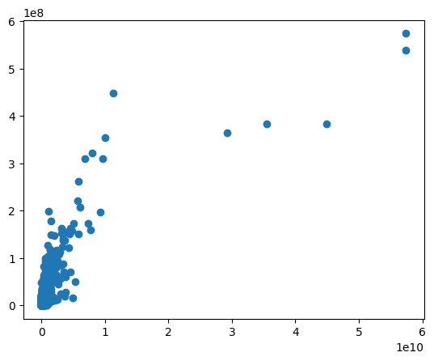

```python
#graphs to see possible linear trends
plt.scatter(df2['Total_Debt_Outstanding'], df2['Water_Utility_Revenue'])
```

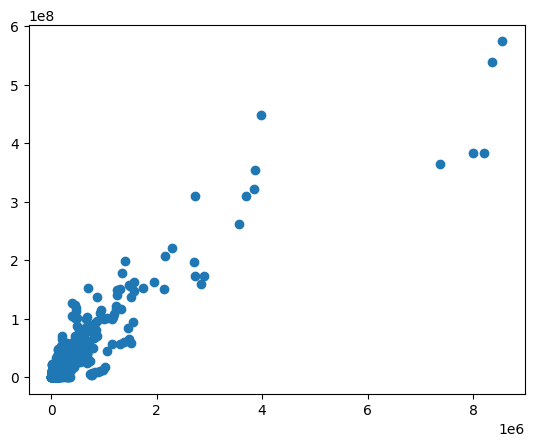

```python
plt.scatter(df2['Population'], df2['Water_Utility_Revenue'])
```

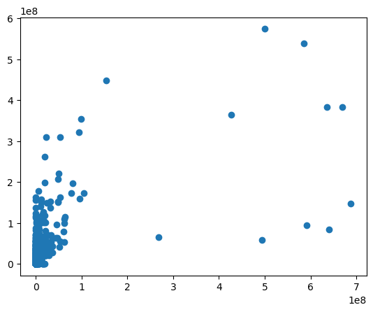

```python
plt.scatter(df2['Health_Total_Expend'], df2['Water_Utility_Revenue'])
#everything is in that bottom left corner so it's hard to make out a trend
```

```python
# Gradient Descent
```

```python
eta = 0.1
n_iterations = 1000 #1000
m = 100
```

```python
# Gradient Descent (Lecture Code)

def grad_descent_ridge(X,y,T,alpha,lam):
    m, n = X.shape
    theta = np.zeros(n)
    #theta = np.array([0.002050, 0.327121, 0.340441, 0.333236, -0.000008])
    f = np.zeros(T)

    for i in range(T):
        f[i] = 0.5*np.linalg.norm(X.dot(theta)-y)**2 #
        #g = np.transpose(X).dot(X.dot(theta)-y)
        g = X.T @ ((X @ theta) - y)
        theta = theta*(1-((alpha*lam)/m)) - (alpha/m)*g
        #lst.append(theta)
    return(theta,f)
```

```python
T = 15000 # T limit is between 0-100 since the data itself has 0-100 values
alpha = 0.000000000000000001 #if this isn't the learning rate then i get -#e+19 as my coefficient which then seems to grow exponentially
lam =  1.00e+04 #kind of reasonable value
X = training_set[['ones', 'Population', 'Health_Total_Expend','Total_Debt_Outstanding']]
y = training_set['Water_Utility_Revenue']
lst=[]
theta,loss = grad_descent_ridge(X,y,T,alpha,lam)

theta
```

```
ones                      5.255889e-08
Population                1.388901e-02
Health_Total_Expend       5.757123e-02
Total_Debt_Outstanding    1.204462e-02
dtype: float64
```

For test data 1 my prediction is 5.255889e-08 + 1.388901e-02(24269.0) + 5.757123e-02(23676.012) + 1.204462e-02(23049844.24) = 279326.74

*Following these calculations:*

test data 2 prediction is: 5.255889e-08 + 1.388901e-02(34683.0) + 5.757123e-02(0) + 1.204462e-02(26671864.25)=321734.18

test data 3 prediction is 5.255889e-08 + 1.388901e-02(35420.0) + 5.757123e-02(0) + 1.204462e-02(24686276.11)=297828.76

test data 4 prediction is 5.255889e-08 + 1.388901e-02(31119.0) + 5.757123e-02(0) + 1.204462e-02(29217910)=352350.83

test data 5 prediction is 5.255889e-08 + 1.388901e-02(24303.0) + 5.757123e-02(75597.55) + 1.204462e-02(27176209)=332016.89

```python
#1/5(actual-prediction)^2 bc n is 5 from mean squared error
test_1 = (1/5)*(0-279326.74)**2 #15604685535.8
test_2 = (1/5)*(0-321734.18)**2 #20702576516.1
day_3 = (1/5)*(0-297828.76)**2 #17740394056.6
day_4 = (1/5)*(0-352350.83)**2 #24830221480.3
day_5 = (1/5)*(0-332016.89)**2 #22047043049.1
```

*Explaining our loss values*

I think my loss was like this because even though I utilized ridge regression, the values of total debt outstanding is much greater then population and health total expend. Furthermore, the values of water utility revenue would often have 0 values for certain years (which just so happened to be all of my test data, so getting to that value is pretty difficult).

**Run this block ONCE**

```python
df3= df #make a copy of the data frame
df3.insert(0, "Source", 0) #Adding a new column called Source. Source will be
# a numerical representation of Primary_Source_Code. Ground water and purchased
# ground water will be coded as a 1 and everything else is a 0

df3.loc[df3["PRIMARY_SOURCE_CODE"]=="GW", "Source"] = 1
df3.loc[df3["PRIMARY_SOURCE_CODE"]=="GWP", "Source"] = 1

df3.head(10) #checking we did it correctly
```

|  | Source | YEAR | State | Census.Name | PWS.Name | GOVSid | Name | Population | Total_Taxes | Water_Utility_Revenue | ... | PCT_White | PCT_Black | PCT_Hispanic | Median_Income | POV_PCT | vio_count | month_moisture | Full_Time_Equivalent_Employees | CPI | PRIMARY_SOURCE_CODE |
| --- | --- | --- | --- | --- | --- | --- | --- | --- | --- | --- | --- | --- | --- | --- | --- | --- | --- | --- | --- | --- | --- |
| 0 | 0 | 1997 | AL | Prattville city | PRATTVILLE (WATER WORKS BOARD OF) | 12001003.0 | PRATTVILLE CITY | 24269.0 | 5.692212e+06 | 0.000 | ... | NaN | NaN | NaN | NaN | NaN | 0 | 0.29 | 265.0 | 160.500 | SWP |
| 1 | 0 | 2012 | AL | Prattville city | PRATTVILLE (WATER WORKS BOARD OF) | 12001003.0 | PRATTVILLE CITY | 34683.0 | 1.156258e+07 | 0.000 | ... | 79.96 | 16.84 | 2.77 | 58773.0 | 9.339197 | 0 | 0.05 | 328.0 | 229.594 | SWP |
| 2 | 0 | 2017 | AL | Prattville city | PRATTVILLE (WATER WORKS BOARD OF) | 12001003.0 | PRATTVILLE CITY | 35420.0 | 1.438194e+07 | 0.000 | ... | 75.03 | 19.20 | 3.94 | 59167.0 | 13.036330 | 0 | 0.38 | 330.0 | 245.120 | SWP |
| 3 | 0 | 2007 | AL | Prattville city | PRATTVILLE (WATER WORKS BOARD OF) | 12001003.0 | PRATTVILLE CITY | 31119.0 | 9.871131e+06 | 0.000 | ... | NaN | NaN | NaN | NaN | NaN | 0 | -0.07 | 347.0 | 207.342 | SWP |
| 8 | 0 | 2002 | AL | Prattville city | PRATTVILLE (WATER WORKS BOARD OF) | 12001003.0 | PRATTVILLE CITY | 24303.0 | 6.468594e+06 | 0.000 | ... | NaN | NaN | NaN | NaN | NaN | 0 | 0.02 | NaN | 179.900 | SWP |
| 22 | 1 | 1997 | AL | Fairhope city | FAIRHOPE WATER SYSTEM (CITY OF) | 12002004.0 | FAIRHOPE CITY | 12045.0 | 1.175701e+06 | 1102180.685 | ... | NaN | NaN | NaN | NaN | NaN | 0 | 0.48 | 177.0 | 160.500 | GW |
| 23 | 1 | 2007 | AL | Fairhope city | FAIRHOPE WATER SYSTEM (CITY OF) | 12002004.0 | FAIRHOPE CITY | 16164.0 | 3.345198e+06 | 2873031.031 | ... | NaN | NaN | NaN | NaN | NaN | 0 | 0.26 | 248.0 | 207.342 | GW |
| 24 | 1 | 2012 | AL | Fairhope city | FAIRHOPE WATER SYSTEM (CITY OF) | 12002004.0 | FAIRHOPE CITY | 16481.0 | 5.438731e+06 | 2801466.937 | ... | 90.81 | 6.07 | 1.20 | 58554.0 | 7.679979 | 0 | 0.32 | 272.0 | 229.594 | GW |
| 25 | 1 | 2017 | AL | Fairhope city | FAIRHOPE WATER SYSTEM (CITY OF) | 12002004.0 | FAIRHOPE CITY | 18730.0 | 7.194027e+06 | 2277251.958 | ... | 92.17 | 5.05 | 5.21 | 66074.0 | 8.793006 | 0 | 0.48 | 339.0 | 245.120 | GW |
| 30 | 1 | 2002 | AL | Fairhope city | FAIRHOPE WATER SYSTEM (CITY OF) | 12002004.0 | FAIRHOPE CITY | 12480.0 | 1.900500e+06 | 1768760.422 | ... | NaN | NaN | NaN | NaN | NaN | 0 | 0.43 | NaN | 179.900 | GW |

10 rows × 25 columns

```python
X= df3[["Population", "Health_Total_Expend", "Total_Debt_Outstanding"]]
Y= df3["Source"]
```

```python
X_train, X_test, Y_train, Y_test= train_test_split(X, Y, test_size= 0.8, random_state= 0)
clf= svm.SVC()
clf.fit(X_train, Y_train)
y_true, y_pred= Y_test, clf.predict(X_test)
```

```python
print(classification_report(y_true, y_pred))
```

```
              precision    recall  f1-score   support

           0       0.66      1.00      0.79      5813
           1       0.00      0.00      0.00      2999

    accuracy                           0.66      8812
   macro avg       0.33      0.50      0.40      8812
weighted avg       0.44      0.66      0.52      8812
```

```python
hinge_loss(y_true, y_pred)
```

```
1.0
```

*Analysis of results*

Our results show that our model is accurate in predicting the whether a municipality uses Ground Water or some other source with 66% accuracy. This is shown to us by looking at the accuracy score in the model's classification report. The model is very good at predicting whether something is not groundwater, but isn't great at predicting if something is groundwater. The model can be used to inform predictions of drinking water source for other municipalities and researchers.

**K-Nearest Neighbors**

The next analytical tool we'll be using to judge the accuracy of our data analysis is K-Nearest Neighbors (KNN). We will be using the KNN metric as a classification tool, making some binary classifications to fit our model and data. This model will be prediciting the classification of two variables (computed separately): Water Utility Revenue and Source. These variables were also used in our SVM model and our linear regression (gradient descent) analysis. KNN is useful for multiclass classification and handling large datasets and predicts using majority class.

```python
# first, we make a copy of the data frame
df4 = df
df4.head(10)
```

|  | Source | YEAR | State | Census.Name | PWS.Name | GOVSid | Name | Population | Total_Taxes | Water_Utility_Revenue | ... | PCT_White | PCT_Black | PCT_Hispanic | Median_Income | POV_PCT | vio_count | month_moisture | Full_Time_Equivalent_Employees | CPI | PRIMARY_SOURCE_CODE |
| --- | --- | --- | --- | --- | --- | --- | --- | --- | --- | --- | --- | --- | --- | --- | --- | --- | --- | --- | --- | --- | --- |
| 0 | 0 | 1997 | AL | Prattville city | PRATTVILLE (WATER WORKS BOARD OF) | 12001003.0 | PRATTVILLE CITY | 24269.0 | 5.692212e+06 | 0.000 | ... | NaN | NaN | NaN | NaN | NaN | 0 | 0.29 | 265.0 | 160.500 | SWP |
| 1 | 0 | 2012 | AL | Prattville city | PRATTVILLE (WATER WORKS BOARD OF) | 12001003.0 | PRATTVILLE CITY | 34683.0 | 1.156258e+07 | 0.000 | ... | 79.96 | 16.84 | 2.77 | 58773.0 | 9.339197 | 0 | 0.05 | 328.0 | 229.594 | SWP |
| 2 | 0 | 2017 | AL | Prattville city | PRATTVILLE (WATER WORKS BOARD OF) | 12001003.0 | PRATTVILLE CITY | 35420.0 | 1.438194e+07 | 0.000 | ... | 75.03 | 19.20 | 3.94 | 59167.0 | 13.036330 | 0 | 0.38 | 330.0 | 245.120 | SWP |
| 3 | 0 | 2007 | AL | Prattville city | PRATTVILLE (WATER WORKS BOARD OF) | 12001003.0 | PRATTVILLE CITY | 31119.0 | 9.871131e+06 | 0.000 | ... | NaN | NaN | NaN | NaN | NaN | 0 | -0.07 | 347.0 | 207.342 | SWP |
| 8 | 0 | 2002 | AL | Prattville city | PRATTVILLE (WATER WORKS BOARD OF) | 12001003.0 | PRATTVILLE CITY | 24303.0 | 6.468594e+06 | 0.000 | ... | NaN | NaN | NaN | NaN | NaN | 0 | 0.02 | NaN | 179.900 | SWP |
| 22 | 1 | 1997 | AL | Fairhope city | FAIRHOPE WATER SYSTEM (CITY OF) | 12002004.0 | FAIRHOPE CITY | 12045.0 | 1.175701e+06 | 1102180.685 | ... | NaN | NaN | NaN | NaN | NaN | 0 | 0.48 | 177.0 | 160.500 | GW |
| 23 | 1 | 2007 | AL | Fairhope city | FAIRHOPE WATER SYSTEM (CITY OF) | 12002004.0 | FAIRHOPE CITY | 16164.0 | 3.345198e+06 | 2873031.031 | ... | NaN | NaN | NaN | NaN | NaN | 0 | 0.26 | 248.0 | 207.342 | GW |
| 24 | 1 | 2012 | AL | Fairhope city | FAIRHOPE WATER SYSTEM (CITY OF) | 12002004.0 | FAIRHOPE CITY | 16481.0 | 5.438731e+06 | 2801466.937 | ... | 90.81 | 6.07 | 1.20 | 58554.0 | 7.679979 | 0 | 0.32 | 272.0 | 229.594 | GW |
| 25 | 1 | 2017 | AL | Fairhope city | FAIRHOPE WATER SYSTEM (CITY OF) | 12002004.0 | FAIRHOPE CITY | 18730.0 | 7.194027e+06 | 2277251.958 | ... | 92.17 | 5.05 | 5.21 | 66074.0 | 8.793006 | 0 | 0.48 | 339.0 | 245.120 | GW |
| 30 | 1 | 2002 | AL | Fairhope city | FAIRHOPE WATER SYSTEM (CITY OF) | 12002004.0 | FAIRHOPE CITY | 12480.0 | 1.900500e+06 | 1768760.422 | ... | NaN | NaN | NaN | NaN | NaN | 0 | 0.43 | NaN | 179.900 | GW |

10 rows × 25 columns

```python
# These are general metrics I've calculated to see how to make some generalizations of the Water_Utility_Revenue data
print(df4['Water_Utility_Revenue'].max())
print(df4['Water_Utility_Revenue'].min())
print(df4['Water_Utility_Revenue'].median())
print(df4['Water_Utility_Revenue'].mean()) # We'll be using this value as a measurement of the data
```

```
574138381.0
0.0
1778193.0
4648256.814069386
```

```python
df4.insert(0, "Water_Revenue", 0) # Adding a new column called Water_Revenue which will be a binary division of the Water_Utility_Revenue data.
# We'll divide the data by assigning a 1 to the values that are greater than or equal to the average, and a zero otherwise. This will help us see whether the
# majority data has a high (classified as >= average) water utility revenue, or low (classified as < average) water utility revenue.

df4.loc[df4["Water_Utility_Revenue"] >= 4648256.8, "Water_Revenue"] = 1 # values whose water utility revenue is greater than the average
df4.head(10) # checking our updated dataframe
```

|  | Water_Revenue | Source | YEAR | State | Census.Name | PWS.Name | GOVSid | Name | Population | Total_Taxes | ... | PCT_White | PCT_Black | PCT_Hispanic | Median_Income | POV_PCT | vio_count | month_moisture | Full_Time_Equivalent_Employees | CPI | PRIMARY_SOURCE_CODE |
| --- | --- | --- | --- | --- | --- | --- | --- | --- | --- | --- | --- | --- | --- | --- | --- | --- | --- | --- | --- | --- | --- |
| 0 | 0 | 0 | 1997 | AL | Prattville city | PRATTVILLE (WATER WORKS BOARD OF) | 12001003.0 | PRATTVILLE CITY | 24269.0 | 5.692212e+06 | ... | NaN | NaN | NaN | NaN | NaN | 0 | 0.29 | 265.0 | 160.500 | SWP |
| 1 | 0 | 0 | 2012 | AL | Prattville city | PRATTVILLE (WATER WORKS BOARD OF) | 12001003.0 | PRATTVILLE CITY | 34683.0 | 1.156258e+07 | ... | 79.96 | 16.84 | 2.77 | 58773.0 | 9.339197 | 0 | 0.05 | 328.0 | 229.594 | SWP |
| 2 | 0 | 0 | 2017 | AL | Prattville city | PRATTVILLE (WATER WORKS BOARD OF) | 12001003.0 | PRATTVILLE CITY | 35420.0 | 1.438194e+07 | ... | 75.03 | 19.20 | 3.94 | 59167.0 | 13.036330 | 0 | 0.38 | 330.0 | 245.120 | SWP |
| 3 | 0 | 0 | 2007 | AL | Prattville city | PRATTVILLE (WATER WORKS BOARD OF) | 12001003.0 | PRATTVILLE CITY | 31119.0 | 9.871131e+06 | ... | NaN | NaN | NaN | NaN | NaN | 0 | -0.07 | 347.0 | 207.342 | SWP |
| 8 | 0 | 0 | 2002 | AL | Prattville city | PRATTVILLE (WATER WORKS BOARD OF) | 12001003.0 | PRATTVILLE CITY | 24303.0 | 6.468594e+06 | ... | NaN | NaN | NaN | NaN | NaN | 0 | 0.02 | NaN | 179.900 | SWP |
| 22 | 0 | 1 | 1997 | AL | Fairhope city | FAIRHOPE WATER SYSTEM (CITY OF) | 12002004.0 | FAIRHOPE CITY | 12045.0 | 1.175701e+06 | ... | NaN | NaN | NaN | NaN | NaN | 0 | 0.48 | 177.0 | 160.500 | GW |
| 23 | 0 | 1 | 2007 | AL | Fairhope city | FAIRHOPE WATER SYSTEM (CITY OF) | 12002004.0 | FAIRHOPE CITY | 16164.0 | 3.345198e+06 | ... | NaN | NaN | NaN | NaN | NaN | 0 | 0.26 | 248.0 | 207.342 | GW |
| 24 | 0 | 1 | 2012 | AL | Fairhope city | FAIRHOPE WATER SYSTEM (CITY OF) | 12002004.0 | FAIRHOPE CITY | 16481.0 | 5.438731e+06 | ... | 90.81 | 6.07 | 1.20 | 58554.0 | 7.679979 | 0 | 0.32 | 272.0 | 229.594 | GW |
| 25 | 0 | 1 | 2017 | AL | Fairhope city | FAIRHOPE WATER SYSTEM (CITY OF) | 12002004.0 | FAIRHOPE CITY | 18730.0 | 7.194027e+06 | ... | 92.17 | 5.05 | 5.21 | 66074.0 | 8.793006 | 0 | 0.48 | 339.0 | 245.120 | GW |
| 30 | 0 | 1 | 2002 | AL | Fairhope city | FAIRHOPE WATER SYSTEM (CITY OF) | 12002004.0 | FAIRHOPE CITY | 12480.0 | 1.900500e+06 | ... | NaN | NaN | NaN | NaN | NaN | 0 | 0.43 | NaN | 179.900 | GW |

10 rows × 26 columns

```python
X.head(10) # just checking our independent variables
```

|  | Population | Health_Total_Expend | Total_Debt_Outstanding |
| --- | --- | --- | --- |
| 0 | 24269.0 | 23676.01246 | 2.304984e+07 |
| 1 | 34683.0 | 0.00000 | 2.667186e+07 |
| 2 | 35420.0 | 0.00000 | 2.468628e+07 |
| 3 | 31119.0 | 0.00000 | 2.921791e+07 |
| 8 | 24303.0 | 75597.55420 | 2.717621e+07 |
| 22 | 12045.0 | 0.00000 | 7.750779e+06 |
| 23 | 16164.0 | 64627.52361 | 1.568327e+07 |
| 24 | 16481.0 | 0.00000 | 1.691421e+07 |
| 25 | 18730.0 | 0.00000 | 1.848564e+07 |
| 30 | 12480.0 | 12229.01612 | 1.126070e+07 |

Now we'll make a KNN model with Source as our dependent variable with respect to Population, Health Total Expend, and Total Outstanding Debt as our independent variables.

```python
# calculating the KNN accuracy for Source

data = shuffle(df4)
X = df4[["Population", "Health_Total_Expend", "Total_Debt_Outstanding"]]
y = np.ravel(df4[['Source']])
X_train,X_test,y_train,y_test = train_test_split(X,y,random_state = 0)

accuracy=[]
for i in range(1, 51):

    knn = KNeighborsClassifier(n_neighbors = i)
    knn.fit(X_train,y_train)
    score = knn.score(X_test,y_test)
    accuracy.append(score)
    print("KNN accuracy for k =", i,':',score)
```

```
KNN accuracy for k = 1 : 0.5813362381989833
KNN accuracy for k = 2 : 0.6372549019607843
KNN accuracy for k = 3 : 0.5933188090050835
KNN accuracy for k = 4 : 0.6339869281045751
KNN accuracy for k = 5 : 0.6096586782861293
KNN accuracy for k = 6 : 0.6343500363108207
KNN accuracy for k = 7 : 0.6230936819172114
KNN accuracy for k = 8 : 0.6350762527233116
KNN accuracy for k = 9 : 0.6216412490922295
KNN accuracy for k = 10 : 0.6365286855482933
KNN accuracy for k = 11 : 0.6256354393609296
KNN accuracy for k = 12 : 0.6437908496732027
KNN accuracy for k = 13 : 0.6350762527233116
KNN accuracy for k = 14 : 0.6430646332607117
KNN accuracy for k = 15 : 0.6310820624546115
KNN accuracy for k = 16 : 0.6470588235294118
KNN accuracy for k = 17 : 0.6390704429920117
KNN accuracy for k = 18 : 0.6466957153231663
KNN accuracy for k = 19 : 0.6336238198983297
KNN accuracy for k = 20 : 0.6474219317356572
KNN accuracy for k = 21 : 0.6361655773420479
KNN accuracy for k = 22 : 0.6463326071169209
KNN accuracy for k = 23 : 0.6372549019607843
KNN accuracy for k = 24 : 0.6445170660856936
KNN accuracy for k = 25 : 0.6412490922294843
KNN accuracy for k = 26 : 0.6470588235294118
KNN accuracy for k = 27 : 0.6423384168482208
KNN accuracy for k = 28 : 0.6477850399419027
KNN accuracy for k = 29 : 0.6412490922294843
KNN accuracy for k = 30 : 0.6503267973856209
KNN accuracy for k = 31 : 0.6499636891793754
KNN accuracy for k = 32 : 0.6546840958605664
KNN accuracy for k = 33 : 0.64960058097313
KNN accuracy for k = 34 : 0.6554103122730573
KNN accuracy for k = 35 : 0.6503267973856209
KNN accuracy for k = 36 : 0.6521423384168482
KNN accuracy for k = 37 : 0.6532316630355846
KNN accuracy for k = 38 : 0.6521423384168482
KNN accuracy for k = 39 : 0.6499636891793754
KNN accuracy for k = 40 : 0.6535947712418301
KNN accuracy for k = 41 : 0.64960058097313
KNN accuracy for k = 42 : 0.6535947712418301
KNN accuracy for k = 43 : 0.6506899055918663
KNN accuracy for k = 44 : 0.6539578794480755
KNN accuracy for k = 45 : 0.64960058097313
KNN accuracy for k = 46 : 0.6532316630355846
KNN accuracy for k = 47 : 0.6521423384168482
KNN accuracy for k = 48 : 0.6535947712418301
KNN accuracy for k = 49 : 0.6514161220043573
KNN accuracy for k = 50 : 0.6554103122730573
```

Next is our KNN model with Water_Revenue as our dependent variable with respect to the same independent variables.

```python
# KNN accuracy for water revenue (Water_Utility_Revenue)

data = shuffle(df4)
X = df4[["Population", "Health_Total_Expend", "Total_Debt_Outstanding"]]
y = np.ravel(df4[['Water_Revenue']])
X_train,X_test,y_train,y_test = train_test_split(X,y,random_state = 0)

accuracy=[]
for i in range(1, 51):
    knn = KNeighborsClassifier(n_neighbors = i)
    knn.fit(X_train,y_train)
    score = knn.score(X_test,y_test)
    accuracy.append(score)
    print("KNN accuracy for k =", i,':',score)
```

```
KNN accuracy for k = 1 : 0.8366013071895425
KNN accuracy for k = 2 : 0.8558460421205519
KNN accuracy for k = 3 : 0.8663761801016703
KNN accuracy for k = 4 : 0.8696441539578794
KNN accuracy for k = 5 : 0.8714596949891068
KNN accuracy for k = 6 : 0.874001452432825
KNN accuracy for k = 7 : 0.8772694262890341
KNN accuracy for k = 8 : 0.874001452432825
KNN accuracy for k = 9 : 0.8761801016702977
KNN accuracy for k = 10 : 0.8761801016702977
KNN accuracy for k = 11 : 0.8772694262890341
KNN accuracy for k = 12 : 0.8769063180827886
KNN accuracy for k = 13 : 0.878721859114016
KNN accuracy for k = 14 : 0.8783587509077705
KNN accuracy for k = 15 : 0.879448075526507
KNN accuracy for k = 16 : 0.8805374001452433
KNN accuracy for k = 17 : 0.8798111837327524
KNN accuracy for k = 18 : 0.8816267247639796
KNN accuracy for k = 19 : 0.8801742919389978
KNN accuracy for k = 20 : 0.8819898329702252
KNN accuracy for k = 21 : 0.8783587509077705
KNN accuracy for k = 22 : 0.8776325344952796
KNN accuracy for k = 23 : 0.8790849673202614
KNN accuracy for k = 24 : 0.8790849673202614
KNN accuracy for k = 25 : 0.8801742919389978
KNN accuracy for k = 26 : 0.8809005083514887
KNN accuracy for k = 27 : 0.8801742919389978
KNN accuracy for k = 28 : 0.8809005083514887
KNN accuracy for k = 29 : 0.8827160493827161
KNN accuracy for k = 30 : 0.8819898329702252
KNN accuracy for k = 31 : 0.8823529411764706
KNN accuracy for k = 32 : 0.8816267247639796
KNN accuracy for k = 33 : 0.8819898329702252
KNN accuracy for k = 34 : 0.8823529411764706
KNN accuracy for k = 35 : 0.8809005083514887
KNN accuracy for k = 36 : 0.8819898329702252
KNN accuracy for k = 37 : 0.8816267247639796
KNN accuracy for k = 38 : 0.8816267247639796
KNN accuracy for k = 39 : 0.8827160493827161
KNN accuracy for k = 40 : 0.8819898329702252
KNN accuracy for k = 41 : 0.8819898329702252
KNN accuracy for k = 42 : 0.8816267247639796
KNN accuracy for k = 43 : 0.8812636165577342
KNN accuracy for k = 44 : 0.8816267247639796
KNN accuracy for k = 45 : 0.8809005083514887
KNN accuracy for k = 46 : 0.8816267247639796
KNN accuracy for k = 47 : 0.8812636165577342
KNN accuracy for k = 48 : 0.8827160493827161
KNN accuracy for k = 49 : 0.8809005083514887
KNN accuracy for k = 50 : 0.8823529411764706
```

*Analysis of our KNN model*

Based off the KNN accuracies of each model, we can see that they closely align with the accuracies of the SVM model and gradient descent for their respective dependent variable. The first model studying the Source has an approximate accuracy in the low to mid 60s, which supports our SVM accuracy of ~66%. The second model using Water Utility Revenue has an approximate accuracy of the mid to high 80s, supporting the strong correlation and positive relationship between the Water Utility Revenue and Population, Total Health Expend, and Total Outstanding Debt.

**Insights and Conclusion**

We've reached the end of our analysis! Let's take a step back and gather our insights to make some general conclusions.

Our data of drinking water types, qualities and other factors were analyzed through our the data science pipeline. From data collection, processing to data analyiss and machine learning, we visualized data and observed differences, relationships, and correlations. The goal of our data analysis were to gain insights in the drinking water infrastructure, safetly, and potential risks in drinking water in the United States.

We analyzed a variety of factors, however we chose to primarly focus on the following variables: population, total health expend, and the total debt outstanding with respect to the water source and water utility revenue. We chose to study these variables because of their relationships; we could assume that higher populations will have higher total health expenditures, total debt which could cause higher water utility revenue and subsequently these factors may be found in the same source.

Through our data visualizations, hypothesis testing, and machine learning models (linear regression analysis via gradient descent and regularization, SVM, KNN) we saw that there is a strong correlation between the water utility revenue and our independent variables. Water utility revenue would also be a measure of how good or clean the water in that specific area might be; if the revenue is higher then that might mean more people drink or use said water because it's cleaner. Testing the effect of population, total health expense and outstanding debt on the water utility revenue in our gradient descent algorithm, our OLS analysis consistently gives us p values less than alpha (0.05), meaning our findings are statistically significant. Meaning, we reject the null hypothesis and can say that there is a relationship between the water utiltiy revenue and the independent variables.

Our SVM models predicts the water source based on our independent variables by predicting a classificaiton. The SVM outputted an accuracy of 0.66, illustrating that the it correctly predicted the water source 66% of the time.

Our KNN model supported the findings from both the SVM model and linear regression analysis, giving us similar accuracies that suggest a relationship between the water utility revenue and the independent variables, as well as the effect our independent variables have on source.

All in all, we can conclude that clean water depends on the size of the population, supporting data for the total health expenses and total outstanding debt.

*Policy*

While the United States have made many strides in creating clean and safe access to water, not all regions share the same experience. It's crucial that we increase this access to everyone across the country, regardless of the state or county they live in. Through our data analysis, we have learned which areas might lack this resource compared to others and its relationship with popultion, health expenses, utility revenues, and debt. Observing these correlations and effects can help data scientists and policymakers to create informed decisions and learn about how they can widen the access to clean and safe drinking water.

We hoped you've learned a little more about the drinking water crisis in the United States, drinking water types and qualities and the factors that might influence it.